# Clustering

## Introducation to Clustering

Clustering is the task of dividing the population or data points into a number of groups such that data points in the same groups are more similar to other data points in the same group than those in other groups. In simple words, the aim is to segregate groups with similar traits and assign them into clusters.

Let’s understand this with an example. Suppose, you are the head of a rental store and wish to understand preferences of your costumers to scale up your business. Is it possible for you to look at details of each costumer and devise a unique business strategy for each one of them? Definitely not. But, what you can do is to cluster all of your costumers into say 10 groups based on their purchasing habits and use a separate strategy for costumers in each of these 10 groups. And this is what we call clustering.

refernce: https://www.analyticsvidhya.com/blog/2016/11/an-introduction-to-clustering-and-different-methods-of-clustering/

## Dataset Introduction

#### New Dataset of Residential power usage 3 years data

There are two datasets in total. The power usage data, extracted from “TRIEAGLE ENERGY LP, The Woodlands, Texas 77393”. and the historical weather data for Houston, Texas extracted from “www.wunderground.com”

For the direction I want to study, I decided to use this ataset is because i want to know how residence use energy in time series. clustering can help me to cluster factors together in order to get more persuasive and accurate result to determine what energy consumption range resident usually is.

Since there are too many factor or value influence the energy consumption, I categorize the value into three different groups in variable `usage`: - high (2): value in kWh >= 1.5 - low (0): value in kWh <= 1.5

also, for better utilize in the future, i convert the `notes` into factors 0-4: - weekday : 0 - weekend : 1 - vacation : 2 - COVID-lockdown : 3

In these datasets, we will use three kinds of methods of clustering and compare their accuracy and feasibility to determine which method is the most suitable to do clustering and reach conclusions.

The three methods of clustering: K means / DBSAN / Hierachical clustering

```python
import pandas as pd
import numpy as np
import matplotlib.pyplot as plt
import seaborn as sns
from statistics import mode
import numpy as np
import pandas as pd
import matplotlib.pyplot as plt
from sklearn.cluster import KMeans
from scipy.spatial.distance import cdist
from sklearn.metrics import classification_report, confusion_matrix, ConfusionMatrixDisplay, accuracy_score
from sklearn.model_selection import train_test_split
from sklearn.preprocessing import StandardScaler
from sklearn.cluster import DBSCAN,KMeans
from sklearn.metrics import silhouette_samples, silhouette_score
from scipy.cluster.hierarchy import dendrogram, linkage
from sklearn.cluster import AgglomerativeClustering

df = pd.read_csv("/Users/crystal/Desktop/anly-501-project-HuitingSong/501-project-website/data/cleaned data/merged_w_u.csv",index_col=[0])
df.head()
```

|  | Value (kWh) | notes | Date | time | Day | Temp_max | Temp_avg | Temp_min | Dew_max | Dew_avg | ... | Hum_min | Wind_max | Wind_avg | Wind_min | Press_max | Press_avg | Press_min | Precipit | day_of_week | year |
| --- | --- | --- | --- | --- | --- | --- | --- | --- | --- | --- | --- | --- | --- | --- | --- | --- | --- | --- | --- | --- | --- |
| 0 | 1.057 | weekday | 2016-01-06 | 00:00:00 | 1 | 85 | 74.8 | 68 | 74 | 71.4 | ... | 65 | 21 | 9.5 | 0 | 29.8 | 29.8 | 29.7 | 0.0 | 2 | 2016 |
| 1 | 1.171 | weekday | 2016-01-06 | 01:00:00 | 1 | 85 | 74.8 | 68 | 74 | 71.4 | ... | 65 | 21 | 9.5 | 0 | 29.8 | 29.8 | 29.7 | 0.0 | 2 | 2016 |
| 2 | 0.560 | weekday | 2016-01-06 | 02:00:00 | 1 | 85 | 74.8 | 68 | 74 | 71.4 | ... | 65 | 21 | 9.5 | 0 | 29.8 | 29.8 | 29.7 | 0.0 | 2 | 2016 |
| 3 | 0.828 | weekday | 2016-01-06 | 03:00:00 | 1 | 85 | 74.8 | 68 | 74 | 71.4 | ... | 65 | 21 | 9.5 | 0 | 29.8 | 29.8 | 29.7 | 0.0 | 2 | 2016 |
| 4 | 0.932 | weekday | 2016-01-06 | 04:00:00 | 1 | 85 | 74.8 | 68 | 74 | 71.4 | ... | 65 | 21 | 9.5 | 0 | 29.8 | 29.8 | 29.7 | 0.0 | 2 | 2016 |

5 rows × 23 columns

clean and EDA

no NA missing

```python
df.isna().sum()
```

```
Value (kWh)    0
notes          0
Date           0
time           0
Day            0
Temp_max       0
Temp_avg       0
Temp_min       0
Dew_max        0
Dew_avg        0
Dew_min        0
Hum_max        0
Hum_avg        0
Hum_min        0
Wind_max       0
Wind_avg       0
Wind_min       0
Press_max      0
Press_avg      0
Press_min      0
Precipit       0
day_of_week    0
year           0
dtype: int64
```

drop columns

```python
df = df.drop(["Day","year","time"],axis=1)
```

change the tyepe the variable `notes` to category

```python
df["notes"] = df["notes"].astype("category")
df["notes"] = df['notes'].replace("weekday","0")
df["notes"] = df["notes"].replace("weekend","1")
df["notes"] = df['notes'].replace("vacation","2")
df["notes"] = df["notes"].replace("COVID_lockdown","3")
```

correlation matrix

```
(18, 18)
```

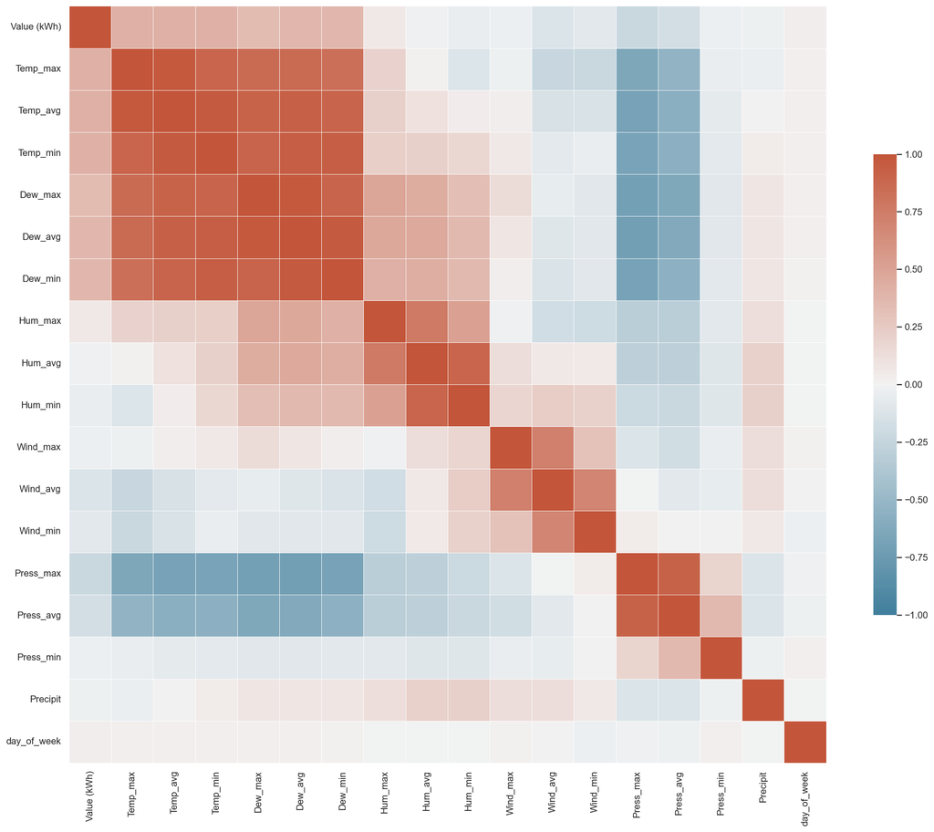

```python
corr = df.corr();
print(corr.shape)
sns.set_theme(style="white")
f, ax = plt.subplots(figsize=(20, 20))
cmap = sns.diverging_palette(230, 20, as_cmap=True)
sns.heatmap(corr,  cmap=cmap, vmin=-1, vmax=1, center=0, square=True, linewidths=.5, cbar_kws={"shrink": .5})
plt.show()
```

## Clustering using Three methods

### 1. K-Means Clustering

K-means clustering (k-means) is a clustering algorithm based on the division of the sample set. K-means clustering divides the sample set into k subsets, which constitute k classes, and divides n samples into k classes, each sample has the smallest distance to the center of the class it belongs to, and each sample belongs to only one class, which is k-means clustering,

This algorithm works in these 5 steps : 1. Specify the desired number of clusters K 2. Randomly assign each data point to a cluster 3. Compute cluster centroids 4. Re-assign each point to the closest cluster centroid 5. Re-compute cluster centroids

**split the dataset**

```python
X = df[['Temp_avg','Value (kWh)']]
scaler = StandardScaler()
X = scaler.fit_transform(X)
```

#### Perform K-Means Clustering

**Fit ino the KMeans model and generate evaluation plot**

```python
distortions = []
inertias = []
k = 11

for k in range(1,k):
    kmeanModel = KMeans(n_clusters=k, init='k-means++', random_state=42)
    kmeanModel.fit(X)

    distortions.append(sum(np.min(cdist(X, kmeanModel.cluster_centers_, 'euclidean'),axis=1))/X.shape[0])
    inertias.append(kmeanModel.inertia_)
    evaluation = pd.DataFrame.from_records({'Cluster':np.arange(1,k+1), 'Distortion':distortions, "Inertia":inertias})

evaluation
```

|  | Cluster | Distortion | Inertia |
| --- | --- | --- | --- |
| 0 | 1 | 1.204823 | 71904.000000 |
| 1 | 2 | 0.896318 | 39405.615309 |
| 2 | 3 | 0.630676 | 18784.763728 |
| 3 | 4 | 0.545818 | 13818.532690 |
| 4 | 5 | 0.457918 | 9819.083498 |
| 5 | 6 | 0.408122 | 8042.640779 |
| 6 | 7 | 0.370698 | 6532.519037 |
| 7 | 8 | 0.352229 | 5842.720015 |
| 8 | 9 | 0.332426 | 5163.627729 |
| 9 | 10 | 0.313321 | 4568.165950 |

**Using Elbow method to determine the number of clusters**

```
Elbow Method to determine the number of clusters to be formed:
```

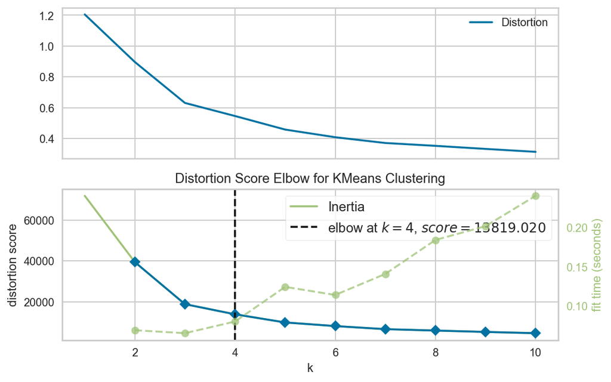

```python
from yellowbrick.cluster import KElbowVisualizer
evaluation.plot.line(x = 'Cluster', subplots=True)

print('Elbow Method to determine the number of clusters to be formed:')
Elbow_M = KElbowVisualizer(KMeans(), k=10)
Elbow_M.fit(X)
Elbow_M.show()
```

**Graph the plot use the number of cluster we choose**

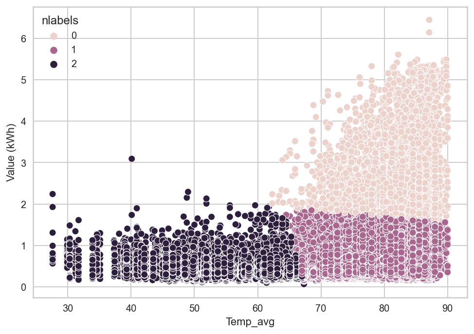

```python
bestK = KMeans(n_clusters=3, init='k-means++',random_state=42)
labels4 = bestK.fit_predict(X)
df['nlabels'] = labels4
sns.scatterplot(x="Temp_avg",y='Value (kWh)',hue='nlabels',data=df)
plt.show()
```

#### Result

When number of cluster is 3, the clustered data has been shown on the graph. We can group the clustered data into 3 groups: - nlabels 2. Low average temperature & Low energy consumption value in kWh - nlabels 1. High average temperature & Low energy consumption value in kWh - nlabels 0. High average temperature & High energy consumption value in kWh

#### Result

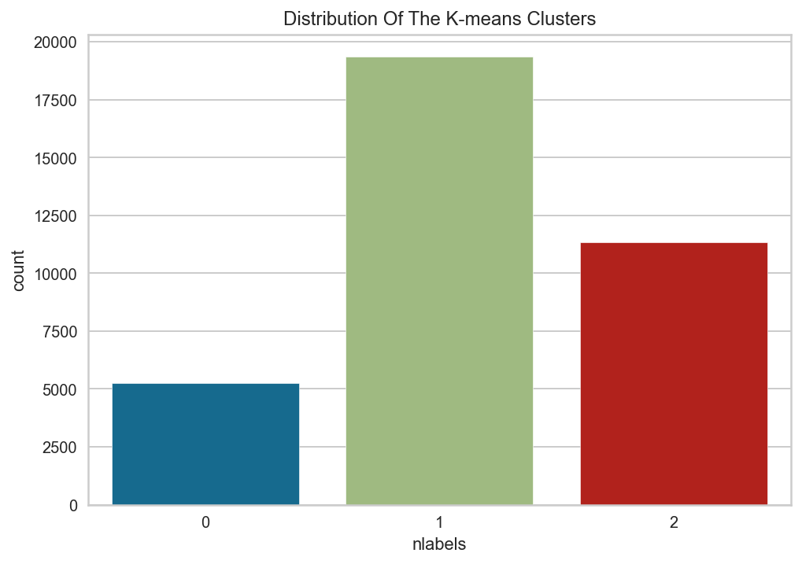

```python
sns.countplot(x=df["nlabels"])
plt.title("Distribution Of The K-means Clusters")
plt.show()
```

From the count plot, we can see most of the points drops into nlabels 1 which is the group which igh average temperature and Low energy consumption value in kWh. The distribution of the K-means clusters is more like normal distribution.

During the data clean I have categorized the `notes` into four levels. Then, I want to see how residences in these three clusters perform in four date type levels.

- Notes:  
  i convert the `notes` into factors 0-4:
  - weekday : 0
  - weekend : 1
  - vacation : 2
  - COVID-lockdown : 3

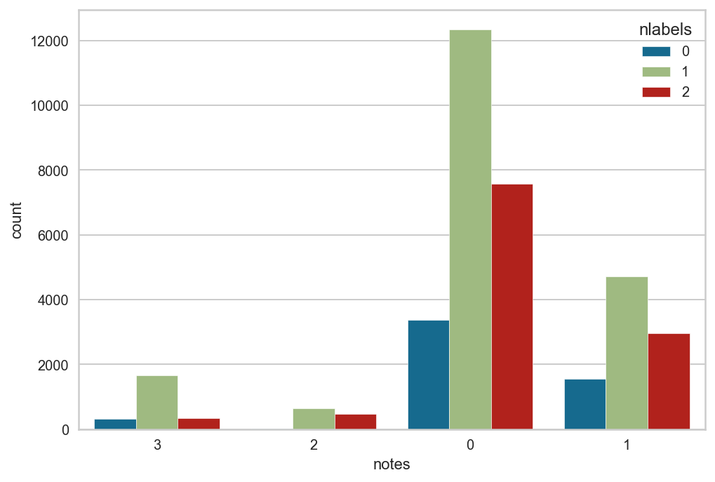

```python
sns.countplot(hue=df["nlabels"], x=df["notes"])
plt.show()
```

As we see from the graph, the three clusters are more likely to happened during weekday. To be more specifically, High average temperature and Low energy consumption value in kWh are more likely to be seen during weekday.

### 2. DBSCAN

The idea is that assuming the categories can be determined by the closeness of the sample distribution, and that samples of the same category, which are closely related to each other, must exist in the same category not far from any sample of that category.

The advantages of DBSCAN are that it does not require a predetermined number of clusters as KMeans does, and is insensitive to outliers. Also he can separate high density data into small clusters and can also cluster non-linear relationships (clustering to arbitrary shapes). However, it also has disadvantages because it is difficult to identify clusters in data of different densities, difficult to cluster high-dimensional data, and very sensitive to parameters of very small points.

#### Perform DBSCAN clustering.

**use the eps and min_samples parameters to find the optimal number of clusters**

```python
eps_range = np.arange(0.1,1.0,0.1)
for i in eps_range:
    db = DBSCAN(eps=i, min_samples=5).fit(X)
    labels = db.labels_
    if len(np.unique(labels)) == 1:
        continue
    silhouette_avg = silhouette_score(X, labels)
    print(
        "For eps = {:0.2f}".format(i),
        "The average silhouette_score is {:0.4f}.".format(silhouette_avg)
    )
```

```
For eps = 0.10 The average silhouette_score is -0.0840.
```

```
For eps = 0.20 The average silhouette_score is 0.3798.
```

```
For eps = 0.30 The average silhouette_score is 0.5297.
```

```
For eps = 0.40 The average silhouette_score is 0.6396.
```

```
For eps = 0.50 The average silhouette_score is 0.6522.
```

```
For eps = 0.60 The average silhouette_score is 0.6522.
```

```
For eps = 0.70 The average silhouette_score is 0.6662.
```

```
For eps = 0.80 The average silhouette_score is 0.5365.
```

```
For eps = 0.90 The average silhouette_score is 0.5365.
```

With the avg silhouette score for eps = 0.6662, we will set the eps as 0.70.

```python
S = np.arange(1,10)
for s in S:
    db = DBSCAN(eps=0.7, min_samples=s).fit(X)
    labels = db.labels_
    if len(np.unique(labels)) == 1:
        continue
    silhouette_avg = silhouette_score(X, labels)
    print(
        "For min_samples = {:0.2f}".format(s),
        "The average silhouette_score is {:0.4f}.".format(silhouette_avg)
    )
```

```
For min_samples = 1.00 The average silhouette_score is 0.5260.
```

```
For min_samples = 2.00 The average silhouette_score is 0.5260.
```

```
For min_samples = 3.00 The average silhouette_score is 0.6662.
```

```
For min_samples = 4.00 The average silhouette_score is 0.6662.
```

```
For min_samples = 5.00 The average silhouette_score is 0.6662.
```

```
For min_samples = 6.00 The average silhouette_score is 0.6662.
```

```
For min_samples = 7.00 The average silhouette_score is 0.6522.
```

```
For min_samples = 8.00 The average silhouette_score is 0.6522.
```

```
For min_samples = 9.00 The average silhouette_score is 0.6522.
```

With the best avg silhouette score, we get the best eps=0.7 and min samples ranges from 3.00 to 6.00. I will choose eps = 0.7 and min_sample =6 as my parameter to do the DBSCAN modelling.

**Fit the the data with eps=0.7 and min_sample=6 to train the model**

[figure not shown]

```python
db = DBSCAN(eps=0.7, min_samples=6).fit(X)

df['Labels'] = db.labels_
plt.figure(figsize=(12, 8))
sns.scatterplot(x=df['Temp_avg'], y=df['Value (kWh)'], hue=df['Labels'],
                palette=sns.color_palette('hls', np.unique(db.labels_).shape[0]))
plt.title('DBSCAN with epsilon 0.2, min samples 5')
plt.show()
```

The DBSCAN algorithm cluster the data into two groups. As the group shown, most of the data are in one huge cluster. In my opinion, the method may not be a suitable clustering method.

#### Result

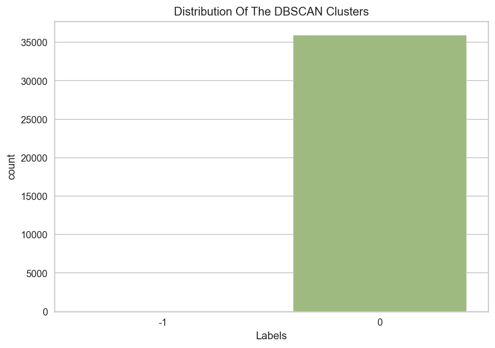

```python
sns.countplot(x=df["Labels"])
plt.title("Distribution Of The DBSCAN Clusters")
plt.show()
```

As we see from the distribution graph. nearly all data are in the Labels 0. Frankly, no clustering at all. Therefore, I think this is not a good model to cluster the dataset.

### 3. Hierarchical Clustering

As the name implies, the clustering is done layer by layer, either by splitting the large categories (cluster) from top to bottom or by aggregating the small categories from bottom to top. Hierarchical clustering methods decompose a given data set hierarchically until certain conditions are met. After distance values have been obtained, elements can be linked to each other. A structure can be constructed by separation and fusion. The method traditionally represented is a Tree data structure.

Hierarchical clustering algorithms are either bottom-up aggregation type, which starts from leaf nodes and eventually converges to the root node, or top-down splitting type, which starts from the root node and recursively splits downward.

#### Perform Agglomerative Clustering

```python
model = AgglomerativeClustering().fit(X)
labels = model.labels_
```

**create linkage for agglomerative clustering, and the dendrogram for the linkage. Suggest the optimal number of clusters based on the dendrogram.**

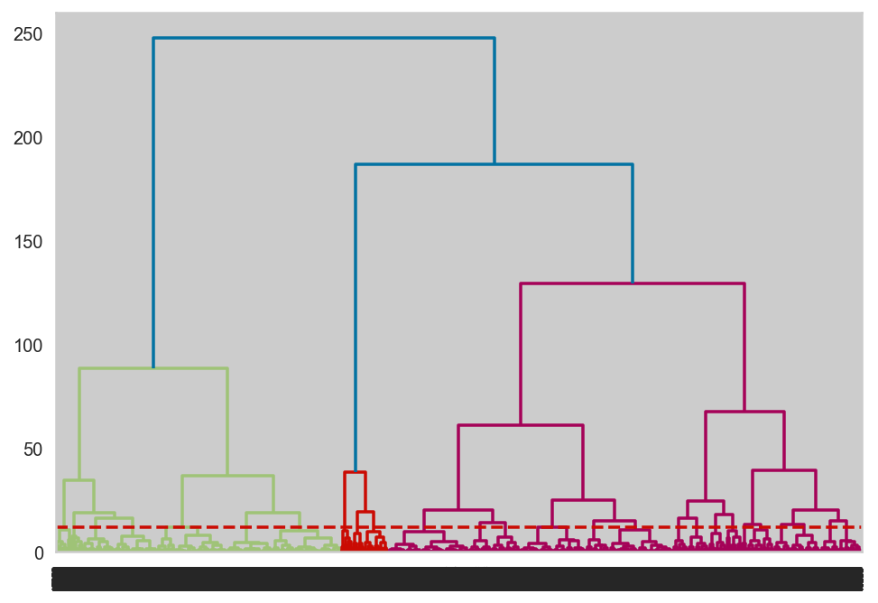

```python
Z = linkage(X, method='ward')
dend = dendrogram(Z)
plt.axhline(y=12,color='r',linestyle='--',label=21)
```

From the dendrogram, I think i should choose the number of clusters as 22 by counting the optimal number of cluster above the line.

**fit model and predict clusters**

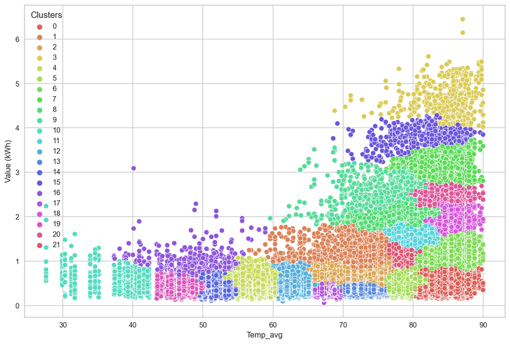

```python
AC = AgglomerativeClustering(n_clusters=22)
yhat_AC = AC.fit_predict(X)
#Adding the Clusters feature to the orignal dataframe.
df["Clusters"]= yhat_AC
plt.figure(figsize=(12, 8))
sns.scatterplot(x=df['Temp_avg'], y=df['Value (kWh)'], hue=df['Clusters'],
                palette=sns.color_palette('hls', np.unique(yhat_AC).shape[0]))
plt.show()
```

As shown on the graph, the Agglomerative Clustering method groups data into many clusters. This clustering may be good since the sample size is large. However, it is difficult to get the cluster infomation under such large number of clusters. Therefore, I will also consider this clustering method as ineffective and not suitable.

#### Result

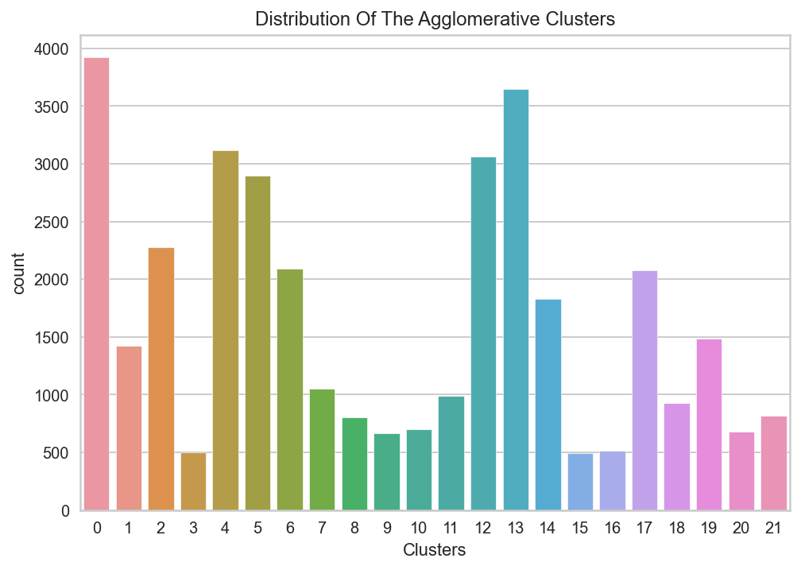

```python
pl = sns.countplot(x=df["Clusters"])
pl.set_title("Distribution Of The Agglomerative Clusters")
plt.show()
```

The distribution of the agglomerative cluster is not bell-shaped. and as I said before, this method groups the data in too many number of clusters, so it is difficult to analyze the result. We need more further study to address this problem.

## Conclusion

Comparing the result of three clustering method (KMeans, DBSCAN, Agglomerative), the best clustering result will be K-Means cluster. We get the data in three clusters or groups and clearly analyze the groups in four different notes type. I conclude that in the weekday of high average temperature, the energy consumption value in kWh will be low.

In common sense, when temperature is high, we tend to open the AC to make us feel better, so then the energy consumption will be high. Here, the cluster infomation shows the opposite. Maybe, in the weekday residence tend to go to work place, the energy consumption at that moment in residence building is low. Thinking in this way, the question will be addressed.